# Estimating ancestral states

Author

Daniel Padfield

Published

November 28, 2022

## 1 Outline

Using information on the tip states of a phylogenetic tree we can use evolutionary models to estimate the ancestral states of internal nodes and transitions between states.

We fit an $Mk$ model of evolution to our tree and habitat preference data to understand how habitat preference evolved. For example does evolution readily allow transitions between specialist habitat preferences (i.e. from marine mud only to terrestrial only).

We also try and fit an $Mk$ model of evolution when we combine two traits together (habitat preference and whether or not the species has high or low diversification rate as identified by BAMM).

Ancestral state reconstructions can also be estimated from the MuSSE and HiSSE models we are aiming to fit later on. These models would have a lot of free parameters and we are unsure whether they can be fit with the dataset we have. We hope to reduce the number of free parameters in those models by estimating the transition matrix which best fits the data in the $Mk$ model. This would reduce the number of free parameters.

## 4 Fitting transition rate models and doing ancestral state reconstructions

We can do ancestral state reconstruction with a couple of different methods in R as well as trying in [BayesTraits](http://www.evolution.reading.ac.uk/BayesTraitsV4.0.0/BayesTraitsV4.0.0.html).

For discrete traits, the most commonly used model for evolution on tree is called the $Mk$ model. $M$ stands for Markov because the modelled process is a continuous-time Markov chain, and $k$ because the model is generalised to include an arbitrary number ($k$) states.

The central attribute of the $Mk$ model is a the transition matrix, $Q$, which gives the instantaneous transition rates between states.

An important distinction in ancestral state reconstruction for discrete characters is joint vs. marginal reconstruction. Joint reconstruction is finding the set of character states at all nodes that maximise the likelihood. Marginal reconstruction is finding the state at the current node that maximises the likelihood integrating over all the other states at all nodes, in proportion to their probability.

We can do both marginal reconstruction using **ape::ace()** and **castor::asr_mk_model()** and joint reconstruction using **ape::ace()**.

An alternative tactic to the one outlined above is to use an MCMC approach to sample character histories from their posterior probability distribution. This is called stochastic character mapping. The model is the same but in this case we get a sample of unambiguous histories for our discrete character’s evolution on the tree - rather than a probability distribution for the character at nodes.

Finally we can use BayesTraits to do both maximum likelihood and MCMC approaches. We do not use this approach in this walk-through.

The evolutionary models that are used to reconstruct ancestral states have a transition matrix between discrete states that define the rates of transitions between states on the tree. In most of these models, there are three that are easy to define: **ARD** means all transition rates are different, **SYM** means transitions to and from the same states are the same, and **ER** is an equal rates model where all rates between states are the same. These transition matrices can also be custom made but for now these three seem sensible starting points. Transition matrices also underpin the MuSSE and BiSSE models we are hoping to fit.

## 5 Load in R packages

First we will load in R packages used and the metadata file used and wrangled in a previous walk-through.

We also load in the final phylogenetic tree, the colours used for habitat preferences, and the position of shift nodes.

```r
# load packages
library(here)
library(tidyverse)
library(ggtree)
library(ggnewscale)
library(RColorBrewer)
library(patchwork)
library(phytools)
library(MetBrewer)
library(ggpp)
library(castor)
library(diversitree)
library(tidygraph)
library(igraph)
library(ggraph)
library(GGally)
library(ggrepel)
library(flextable)
library(ggridges)

# set where I am in the project
here::i_am('scripts/sequencing_rpoB/analyses/estimating_transition_rates_v3.qmd')

# read in metadata
d_meta <- read.csv(here('data/sequencing_rpoB/processed/asv_metadata.csv'))

# read in tree
tree <- read.tree(here('data/sequencing_rpoB/bamm/rerooted-pruned-chronopl10.tre'))

# edit tree labels
d_labels <- data.frame(tip_label = tree$tip.label) %>%
  separate(., tip_label, c('part1', 'part2', 'part3'), sep = '_', remove = FALSE) %>%
  unite('tip_label_new', c(part1, part2), sep = '_')

tree$tip.label <- d_labels$tip_label_new

# read in shift nodes
shiftnodes <- readRDS(here('data/sequencing_rpoB/processed/shiftnodes.rds'))
```

## 6 Custom function

We will write a custom function for getting the transition matrix into a format that is easy to plot using **ggplot2**.

```r
# function for getting a data frame from a diversitree object
get_diversitree_df <- function(div_obj, trait_vec, replace_vec){

  temp <- tibble(param = names(div_obj$par.full)) %>%
    mutate(state_1_num = as.numeric(substr(param, 2,2)),
         state_2_num = as.numeric(substr(param, 3,3)),
         transition_rate = unlist(div_obj$par.full),
         state_1 = stringi::stri_replace_all_regex(state_1_num, pattern = trait_vec, replacement = replace_vec, vectorize=FALSE),
         state_2 = stringi::stri_replace_all_regex(state_2_num, pattern = trait_vec, replacement = replace_vec, vectorize=FALSE)) %>%
    select(param, state_1, state_2, state_1_num, state_2_num, transition_rate) %>%
    mutate(free_param = ifelse(param %in% names(div_obj$par), 'yes', 'no'),
           num_params = length(div_obj$par))

  return(temp)

}
```

## 7 Create a master dataframe for the trait states

Different methods for estimating ancestral states take different values for the traits. Some only allow for numeric values, whereas others allow characters. Some do not allow colons in the name, and one (MBASR which uses Mr Bayes) needs the first trait value to be 0. To allow for us to semi-easily link across different methods, we will make a data frame of our unique tip states and then turn them into a numeric vector. The ordering is all done alphabetically.

```r
d_meta <- tibble(tip_label = tree$tip.label) %>%
  left_join(., d_meta)

# make sure order of habitat preference is the same in the trait vector as the tip labels
sum(d_meta$tip_label == tree$tip.label) == length(tree$tip.label)
```

```
[1] TRUE
```

```r
# SUCCESS if TRUE

# replace NA of outgroup - make it freshwater:terrestrial - the most common state
# phytools::make.simmap cannot take NAs
hab_pref <- setNames(d_meta$habitat_preference, d_meta$tip_label)
hab_pref[is.na(hab_pref)] <- 'freshwater:terrestrial'

# make habitat preference vector numeric
hab_pref_num <- as.numeric(as.factor(hab_pref)) -1
hab_pref_num <- setNames(hab_pref_num, d_meta$tip_label)
hab_pref_num2 <- hab_pref_num + 1

# coding from numeric to character
coding <- tibble(hab_pref = unname(hab_pref), hab_pref_num = unname(hab_pref_num)) %>%
  distinct() %>%
  mutate(hab_pref2 = gsub(':', '.', hab_pref),
         hab_pref_num2 = hab_pref_num + 1) %>%
  arrange(hab_pref) %>%
  mutate(hab_pref_axis = gsub(':', '/ ', hab_pref),
  hab_pref_axis = gsub('_', ' ', hab_pref_axis),
  # rename the columns for easy naming
  initials = c('F', 'FM', 'FT', 'G', 'M', 'MT', 'T'))

coding
```

```
# A tibble: 7 × 6
  hab_pref                  hab_pref_num hab_pref2       hab_p…¹ hab_p…² initi…³
  <chr>                            <dbl> <chr>             <dbl> <chr>   <chr>
1 freshwater                           0 freshwater            1 freshw… F
2 freshwater:mud_and_shore             1 freshwater.mud…       2 freshw… FM
3 freshwater:terrestrial               2 freshwater.ter…       3 freshw… FT
4 generalist                           3 generalist            4 genera… G
5 mud_and_shore                        4 mud_and_shore         5 mud an… M
6 mud_and_shore:terrestrial            5 mud_and_shore.…       6 mud an… MT
7 terrestrial                          6 terrestrial           7 terres… T
# … with abbreviated variable names ¹hab_pref_num2, ²hab_pref_axis, ³initials
```

This results in a dataframe which allows us to easily link between numeric and character values, and also gives us a vector - of the same length of tips in our tree - which we can use for estimating ancestral states.

## 8 Estimate ancestral states using diversitree::fit_mk()

First lets fit each of the models (ER, SYM, and ARD) using **diversitree::fit_mk()**. We can compare these models using AIC and likelihood ratio tests to see which model fits the tree best.

**diversitree** is good because it makes us implicitly code the transitions we want to set to 0 or make equivalent, which aids our understanding of the models we are trying to fit. Its downside is that it takes numbers only, so we have to back-transform our model estimates into their biologically meaningful trait values.

[output not shown]

[output not shown]

[output not shown]

```r
# all of these methods needs a likelihood function, we can build a Mkn model
lik_ard <- make.mkn(tree, hab_pref_num2, k = max(hab_pref_num2))

argnames(lik_ard)

# make symmetric rates model
lik_sym <- constrain(lik_ard,
                     q12~q21, q13~q31, q14~q41, q15~q51, q16~q61, q17~q71,
                     q23~q32, q24~q42, q25~q52, q26~q62, q27~q72,
                     q34~q43, q35~q53, q36~q63, q37~q73,
                     q45~q54, q46~q64, q47~q74,
                     q56~q65, q57~q75,
                     q67~q76
                     )

argnames(lik_sym)

# make equal rates model
lik_er <- constrain.i(lik_ard, rep('q12', length(argnames(lik_ard))), i.free = 1)

lik_er <- constrain(lik_ard,
                    q13~q12, q14~q12, q15~q12, q16~q12, q17~q12,
                    q21~q12, q23~q12, q24~q12, q25~q12, q26~q12, q27~q12,
                    q31~q12, q32~q12, q34~q12, q35~q12, q36~q12, q37~q12,
                    q41~q12, q42~q12, q43~q12, q45~q12, q46~q12, q47~q12,
                    q51~q12, q52~q12, q53~q12, q54~q12, q56~q12, q57~q12,
                    q61~q12, q62~q12, q63~q12, q64~q12, q65~q12, q67~q12,
                    q71~q12, q72~q12, q73~q12, q74~q12, q75~q12, q76~q12)

argnames(lik_er)

# need to pass start values to it - can grab these from the ape::ace, but we will just pass an average rate to the model
inits_ard <- rep(1, length(argnames(lik_ard)))
inits_sym <- rep(1, length(argnames(lik_sym)))
inits_er <- rep(1, length(argnames(lik_er)))

# find the maximum likelihood estimates of this model
mod_er <- find.mle(lik_er, inits_er, method = 'subplex', control = list(maxit = 50000))
mod_sym <- find.mle(lik_sym, inits_sym, method = 'subplex', control = list(maxit = 50000))
mod_ard <- find.mle(lik_ard, inits_ard, method = 'subplex', control = list(maxit = 50000))

AIC(mod_er)
AIC(mod_sym)
AIC(mod_ard)
```

We can compare model fit using AIC and anovas

```r
AIC(mod_sym, mod_ard, mod_er) %>% arrange(AIC)
```

```
        df       AIC
mod_ard 42  8425.270
mod_sym 21  8583.008
mod_er   1 10550.367
```

```r
anova(mod_ard, mod_sym)
```

```
        Df   lnLik    AIC  ChiSq Pr(>|Chi|)
full    42 -4170.6 8425.3
model 1 21 -4270.5 8583.0 199.74  < 2.2e-16 ***
---
Signif. codes:  0 '***' 0.001 '**' 0.01 '*' 0.05 '.' 0.1 ' ' 1
```

```r
anova(mod_ard, mod_er)
```

```
        Df   lnLik     AIC  ChiSq Pr(>|Chi|)
full    42 -4170.6  8425.3
model 1  1 -5274.2 10550.4 2207.1  < 2.2e-16 ***
---
Signif. codes:  0 '***' 0.001 '**' 0.01 '*' 0.05 '.' 0.1 ' ' 1
```

### 8.1 Model simplificiation of the ARD model

So the ARD model is the best model by a considerable margin using AIC. We can do model simplification of this model to see what parameters can be removed to further improve the model. First we will just plot the distribution of estimated parameters. As most rates are very small we shall do another histogram filtering out the larger rates.

```r
# look at paraemters
mod_ard$par
```

```
         q12          q13          q14          q15          q16          q17
8.716845e-01 1.206264e+00 7.443013e-02 2.149132e-01 1.801145e-08 1.071351e-02
         q21          q23          q24          q25          q26          q27
4.154994e+00 6.857527e+00 7.739098e-01 9.593800e-01 1.185739e-08 2.998205e-07
         q31          q32          q34          q35          q36          q37
1.386353e+00 4.221782e-01 1.675857e-01 6.395810e-08 2.277816e-06 6.448489e+00
         q41          q42          q43          q45          q46          q47
4.263533e+00 1.351796e-06 1.186039e+01 1.999134e+00 2.658047e-07 3.191294e-06
         q51          q52          q53          q54          q56          q57
8.229576e-02 1.064553e-01 2.187437e-07 6.575989e-09 3.733827e-01 8.844709e-02
         q61          q62          q63          q64          q65          q67
1.157990e+00 6.908942e+00 1.326230e-07 3.191827e-06 6.397722e+00 5.130260e+00
         q71          q72          q73          q74          q75          q76
6.450703e-02 2.437002e-08 8.029773e+00 8.912959e-08 5.539168e-02 2.075544e-01
```

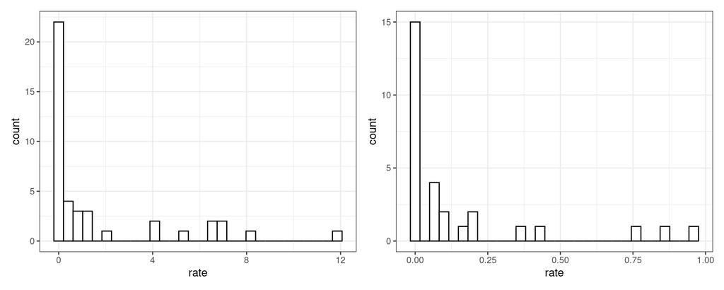

```r
# plot of all parameters
p1 <- tibble(rate = mod_ard$par) %>%
  ggplot(., aes(rate)) +
  geom_histogram(fill = 'white', col = 'black') +
  theme_bw()

# plot of constrained x axis (rates <1)
p2 <- tibble(rate = mod_ard$par) %>%
  filter(rate < 1) %>%
  ggplot(., aes(rate)) +
  geom_histogram(fill = 'white', col = 'black') +
  theme_bw()

p1+p2
```

```r
# sort parameter estimates
mod_ard$par %>% sort()
```

```
         q54          q26          q16          q72          q35          q74
6.575989e-09 1.185739e-08 1.801145e-08 2.437002e-08 6.395810e-08 8.912959e-08
         q63          q53          q46          q27          q42          q36
1.326230e-07 2.187437e-07 2.658047e-07 2.998205e-07 1.351796e-06 2.277816e-06
         q47          q64          q17          q75          q71          q14
3.191294e-06 3.191827e-06 1.071351e-02 5.539168e-02 6.450703e-02 7.443013e-02
         q51          q57          q52          q34          q76          q15
8.229576e-02 8.844709e-02 1.064553e-01 1.675857e-01 2.075544e-01 2.149132e-01
         q56          q32          q24          q12          q25          q61
3.733827e-01 4.221782e-01 7.739098e-01 8.716845e-01 9.593800e-01 1.157990e+00
         q13          q31          q45          q21          q41          q67
1.206264e+00 1.386353e+00 1.999134e+00 4.154994e+00 4.263533e+00 5.130260e+00
         q65          q37          q23          q62          q73          q43
6.397722e+00 6.448489e+00 6.857527e+00 6.908942e+00 8.029773e+00 1.186039e+01
```

```r
# get parameters close to 0.
mod_ard$par[mod_ard$par < 1e-03] %>% names(.)
```

```
 [1] "q16" "q26" "q27" "q35" "q36" "q42" "q46" "q47" "q53" "q54" "q63" "q64"
[13] "q72" "q74"
```

```r
# make custom matrix model
lik_custom1 <- constrain(lik_ard,
                     q16~0, q26~0, q27~0, q35~0, q36~0, q42~0, q46~0, q47~0, q53~0, q54~0, q63~0, q64~0, q72~0, q74~0)

# make start parameters
inits_custom1 <- rep(1, length(argnames(lik_custom1)))

# run model
mod_custom1 <- find.mle(lik_custom1, inits_custom1, method = 'subplex', control = list(maxit = 50000))
```

We can now do model comparison again.

```r
# do AIC comparison
AIC(mod_sym, mod_ard, mod_er, mod_custom1) %>% arrange(AIC)
```

```
            df       AIC
mod_custom1 28  8397.270
mod_ard     42  8425.270
mod_sym     21  8583.008
mod_er       1 10550.367
```

```r
# anova
anova(mod_ard, mod_custom1)
```

```
        Df   lnLik    AIC       ChiSq Pr(>|Chi|)
full    42 -4170.6 8425.3
model 1 28 -4170.6 8397.3 -6.7305e-05          1
```

This model is loads better again. We can again look at the distribution of rates to see how they look.

```r
# filter for only estimated parameters
mod_custom1$par.full[names(mod_custom1$par.full) %in% argnames(lik_custom1)]
```

```
        q12         q13         q14         q15         q17         q21
 0.87163154  1.20712843  0.07449286  0.21487274  0.01013323  4.15434121
        q23         q24         q25         q31         q32         q34
 6.85635520  0.77348625  0.96009812  1.38693426  0.42215216  0.16757930
        q37         q41         q43         q45         q51         q52
 6.45571919  4.26461755 11.85925444  1.99850377  0.08233994  0.10661014
        q56         q57         q61         q62         q65         q67
 0.37353262  0.08813974  1.15622725  6.90144450  6.39594023  5.14300589
        q71         q73         q75         q76
 0.06399512  8.03912271  0.05536596  0.20760093
```

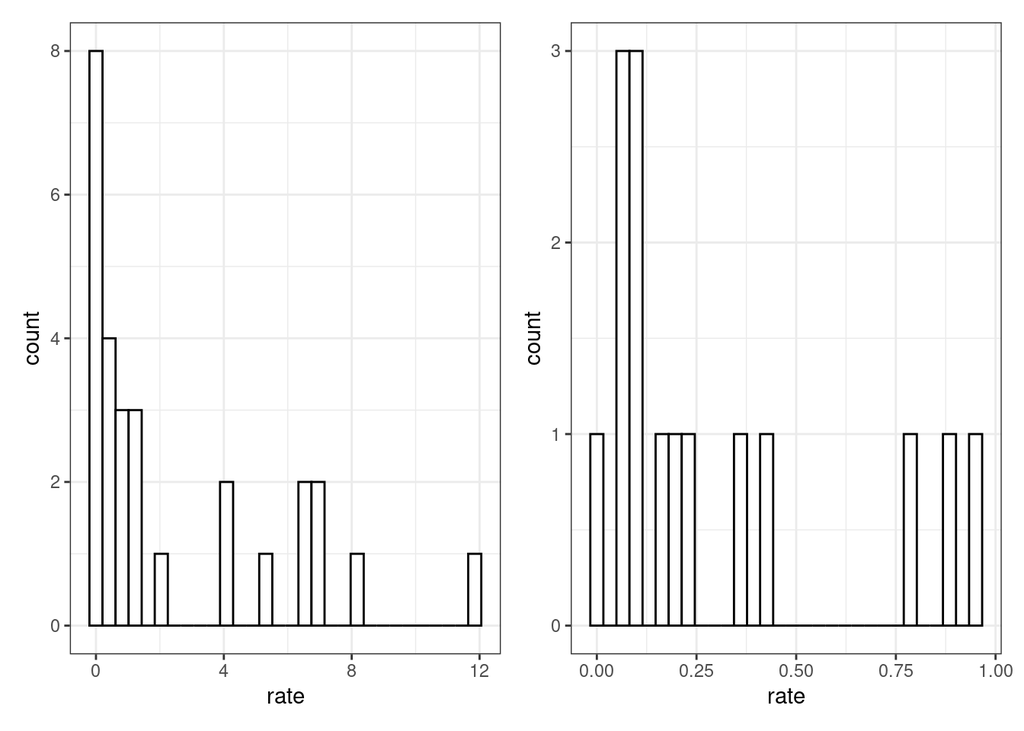

```r
# plot of all parameters
p1 <- tibble(rate = mod_custom1$par.full[names(mod_custom1$par.full) %in% argnames(lik_custom1)]) %>%
  ggplot(., aes(rate)) +
  geom_histogram(fill = 'white', col = 'black') +
  theme_bw()

# plot of constrained x axis (rates <1)
p2 <- tibble(rate = mod_custom1$par.full[names(mod_custom1$par.full) %in% argnames(lik_custom1)]) %>%
  filter(rate < 1) %>%
  ggplot(., aes(rate)) +
  geom_histogram(fill = 'white', col = 'black') +
  theme_bw()

p1+p2
```

```r
# sort parameter estimates
mod_custom1$par %>% sort()
```

```
        q17         q75         q71         q14         q51         q57
 0.01013323  0.05536596  0.06399512  0.07449286  0.08233994  0.08813974
        q52         q34         q76         q15         q56         q32
 0.10661014  0.16757930  0.20760093  0.21487274  0.37353262  0.42215216
        q24         q12         q25         q61         q13         q31
 0.77348625  0.87163154  0.96009812  1.15622725  1.20712843  1.38693426
        q45         q21         q41         q67         q65         q37
 1.99850377  4.15434121  4.26461755  5.14300589  6.39594023  6.45571919
        q23         q62         q73         q43
 6.85635520  6.90144450  8.03912271 11.85925444
```

The lowest rate (q17) is around five times smaller than the other low rates. So we shall remove this rate first and compare models.

```r
# make custom matrix model
lik_custom2 <- constrain(lik_ard,
                     q16~0, q26~0, q27~0, q35~0, q36~0, q42~0, q46~0, q47~0, q53~0, q54~0, q63~0, q64~0, q72~0, q74~0, q17~0)

# make start parameters
inits_custom2 <- rep(1, length(argnames(lik_custom2)))

# run model
mod_custom2 <- find.mle(lik_custom2, inits_custom2, method = 'subplex', control = list(maxit = 50000))
```

We can now again do model comparison.

```r
# do AIC comparison
AIC(mod_sym, mod_ard, mod_er, mod_custom1, mod_custom2) %>% arrange(AIC)
```

```
            df       AIC
mod_custom2 27  8395.272
mod_custom1 28  8397.270
mod_ard     42  8425.270
mod_sym     21  8583.008
mod_er       1 10550.367
```

```r
# anova
anova(mod_custom1, mod_custom2)
```

```
        Df   lnLik    AIC     ChiSq Pr(>|Chi|)
full    28 -4170.6 8397.3
model 1 27 -4170.6 8395.3 0.0021237     0.9632
```

```r
# sort parameter estimates
mod_custom2$par %>% sort()
```

```
        q75         q71         q14         q51         q57         q52
 0.05536530  0.06337126  0.07440475  0.08237575  0.08836391  0.10646024
        q34         q76         q15         q56         q32         q24
 0.16760816  0.20762960  0.21503969  0.37346048  0.42222452  0.77433937
        q12         q25         q61         q13         q31         q45
 0.87200119  0.95918145  1.15299697  1.21780763  1.38818400  1.99757127
        q21         q41         q67         q65         q37         q23
 4.15679163  4.26272095  5.13514787  6.39942919  6.48740330  6.85676508
        q62         q73         q43
 6.90919941  8.07191606 11.86457232
```

This model is once again better. We will do the same procedure to remove the next parameters that are extremely low. We can see that q75 and q71 are both extremely low and similar (difference is ~0.008). We will remove q75 first.

```r
# make custom matrix model
lik_custom3 <- constrain(lik_ard,
                     q16~0, q26~0, q27~0, q35~0, q36~0, q42~0, q46~0, q47~0, q53~0, q54~0, q63~0, q64~0, q72~0, q74~0, q17~0, q75~0)

# make start parameters
inits_custom3 <- rep(1, length(argnames(lik_custom3)))

# run model
mod_custom3 <- find.mle(lik_custom3, inits_custom3, method = 'subplex', control = list(maxit = 50000))
```

We can now again do model comparison.

```r
# do AIC comparison
AIC(mod_sym, mod_ard, mod_er, mod_custom1, mod_custom2, mod_custom3) %>% arrange(AIC)
```

```
            df       AIC
mod_custom3 26  8394.738
mod_custom2 27  8395.272
mod_custom1 28  8397.270
mod_ard     42  8425.270
mod_sym     21  8583.008
mod_er       1 10550.367
```

```r
# anova
anova(mod_custom2, mod_custom3)
```

```
        Df   lnLik    AIC ChiSq Pr(>|Chi|)
full    27 -4170.6 8395.3
model 1 26 -4171.4 8394.7 1.466      0.226
```

```r
# sort parameter estimates
mod_custom3$par %>% sort()
```

```
        q71         q14         q51         q57         q52         q34
 0.04885270  0.07257477  0.07584368  0.08376002  0.09832778  0.17742421
        q15         q76         q32         q56         q24         q12
 0.21416578  0.27819716  0.42383826  0.43013515  0.79760118  0.86543222
        q25         q13         q31         q61         q45         q21
 1.00506278  1.22591287  1.39979875  1.65379334  2.30413554  4.06006994
        q41         q67         q37         q23         q62         q73
 4.21687987  5.61315119  6.50342058  6.86183261  7.17164397  8.09872062
        q65         q43
 9.13367018 12.14580620
```

This model is once again better. We will do the same procedure to remove the next parameters that are extremely low. We will now remove q71.

```r
# make custom matrix model
lik_custom4 <- constrain(lik_ard,
                     q16~0, q26~0, q27~0, q35~0, q36~0, q42~0, q46~0, q47~0, q53~0, q54~0, q63~0, q64~0, q72~0, q74~0, q17~0, q75~0, q71~0)

# make start parameters
inits_custom4 <- rep(1, length(argnames(lik_custom4)))

# run model
mod_custom4 <- find.mle(lik_custom4, inits_custom4, method = 'subplex', control = list(maxit = 50000))
```

We can now again do model comparison.

```r
# do AIC comparison
AIC(mod_sym, mod_ard, mod_er, mod_custom1, mod_custom2, mod_custom3, mod_custom4) %>% arrange(AIC)
```

```
            df       AIC
mod_custom4 25  8392.778
mod_custom3 26  8394.738
mod_custom2 27  8395.272
mod_custom1 28  8397.270
mod_ard     42  8425.270
mod_sym     21  8583.008
mod_er       1 10550.367
```

```r
# anova
anova(mod_custom3, mod_custom4)
```

```
        Df   lnLik    AIC    ChiSq Pr(>|Chi|)
full    26 -4171.4 8394.7
model 1 25 -4171.4 8392.8 0.039906     0.8417
```

```r
# sort parameter estimates
mod_custom4$par %>% sort()
```

```
        q51         q14         q57         q52         q34         q15
 0.07123080  0.07271177  0.08983381  0.09481381  0.17704738  0.21271518
        q76         q32         q56         q24         q12         q25
 0.28080050  0.42222601  0.43379579  0.80143123  0.86805704  1.00752109
        q13         q31         q61         q45         q21         q41
 1.22424084  1.44051575  1.95842256  2.30777674  4.02978430  4.20147991
        q67         q37         q23         q62         q73         q65
 5.30900406  6.54890630  6.89868624  7.34457581  8.19538619  9.26039038
        q43
12.16584786
```

Again the model fits better. q51 and q14 are essentially equivalent, so we will now remove them both at once.

```r
# make custom matrix model
lik_custom5 <- constrain(lik_ard,
                     q16~0, q26~0, q27~0, q35~0, q36~0, q42~0, q46~0, q47~0, q53~0, q54~0, q63~0, q64~0, q72~0, q74~0, q17~0, q75~0, q71~0, q51~0, q14~0)

# make start parameters
inits_custom5 <- rep(1, length(argnames(lik_custom5)))

# run model
mod_custom5 <- find.mle(lik_custom5, inits_custom5, method = 'subplex', control = list(maxit = 50000))
```

We can now again do model comparison.

```r
# do AIC comparison
AIC(mod_sym, mod_ard, mod_er, mod_custom1, mod_custom2, mod_custom3, mod_custom4, mod_custom5) %>% arrange(AIC)
```

```
            df       AIC
mod_custom5 23  8389.555
mod_custom4 25  8392.778
mod_custom3 26  8394.738
mod_custom2 27  8395.272
mod_custom1 28  8397.270
mod_ard     42  8425.270
mod_sym     21  8583.008
mod_er       1 10550.367
```

```r
# anova
anova(mod_custom4, mod_custom5)
```

```
        Df   lnLik    AIC   ChiSq Pr(>|Chi|)
full    25 -4171.4 8392.8
model 1 23 -4171.8 8389.6 0.77718      0.678
```

```r
# sort parameter estimates
mod_custom5$par %>% sort()
```

```
        q52         q57         q34         q15         q76         q32
 0.05737871  0.15883378  0.18332612  0.20745094  0.30088265  0.41750826
        q56         q25         q12         q13         q24         q31
 0.50505334  0.92343218  0.92946931  1.22714244  1.37707484  1.40870400
        q67         q45         q21         q41         q61         q37
 1.83038385  2.69297256  3.93585051  4.40716471  5.70910360  6.50865199
        q23         q73         q62         q65         q43
 6.89714377  8.08552479  9.28185364 11.00150234 12.78663180
```

```r
# make custom matrix model
lik_custom6 <- constrain(lik_ard,
                     q16~0, q26~0, q27~0, q35~0, q36~0, q42~0, q46~0, q47~0, q53~0, q54~0, q63~0, q64~0, q72~0, q74~0, q17~0, q75~0, q71~0, q51~0, q14~0, q52~0)

# make start parameters
inits_custom6 <- rep(1, length(argnames(lik_custom6)))

# run model
mod_custom6 <- find.mle(lik_custom6, inits_custom6, method = 'subplex', control = list(maxit = 50000))
```

We can now again do model comparison.

```r
# do AIC comparison
AIC(mod_sym, mod_ard, mod_er, mod_custom1, mod_custom2, mod_custom3, mod_custom4, mod_custom5, mod_custom6) %>% arrange(AIC)
```

```
            df       AIC
mod_custom6 22  8387.679
mod_custom5 23  8389.555
mod_custom4 25  8392.778
mod_custom3 26  8394.738
mod_custom2 27  8395.272
mod_custom1 28  8397.270
mod_ard     42  8425.270
mod_sym     21  8583.008
mod_er       1 10550.367
```

```r
# anova
anova(mod_custom5, mod_custom6)
```

```
        Df   lnLik    AIC   ChiSq Pr(>|Chi|)
full    23 -4171.8 8389.6
model 1 22 -4171.8 8387.7 0.12448     0.7242
```

```r
# sort parameter estimates
mod_custom6$par %>% sort()
```

```
         q67          q34          q57          q15          q76          q32
1.559283e-05 1.799059e-01 1.968854e-01 2.074353e-01 3.081655e-01 4.062996e-01
         q56          q25          q12          q13          q24          q31
5.441432e-01 8.950325e-01 9.352574e-01 1.218001e+00 1.398937e+00 1.406162e+00
         q45          q21          q41          q61          q37          q23
2.686257e+00 3.903911e+00 4.453345e+00 6.032018e+00 6.548582e+00 7.019443e+00
         q73          q62          q65          q43
8.110025e+00 1.183803e+01 1.186912e+01 1.270400e+01
```

Weirdly q67 has suddenly become really really small, compared to being 1.83 in the previous model. We can remove it and see how the model does.

```r
# make custom matrix model
lik_custom7 <- constrain(lik_ard,
                     q16~0, q26~0, q27~0, q35~0, q36~0, q42~0, q46~0, q47~0, q53~0, q54~0, q63~0, q64~0, q72~0, q74~0, q17~0, q75~0, q71~0, q51~0, q14~0, q52~0, q67~0)

# make start parameters
inits_custom7 <- rep(1, length(argnames(lik_custom7)))

# run model
mod_custom7 <- find.mle(lik_custom7, inits_custom7, method = 'subplex', control = list(maxit = 50000))
```

We can now again do model comparison.

```r
# do AIC comparison
AIC(mod_sym, mod_ard, mod_er, mod_custom1, mod_custom2, mod_custom3, mod_custom4, mod_custom5, mod_custom6, mod_custom7) %>% arrange(AIC)
```

```
            df       AIC
mod_custom7 21  8385.680
mod_custom6 22  8387.679
mod_custom5 23  8389.555
mod_custom4 25  8392.778
mod_custom3 26  8394.738
mod_custom2 27  8395.272
mod_custom1 28  8397.270
mod_ard     42  8425.270
mod_sym     21  8583.008
mod_er       1 10550.367
```

```r
# anova
anova(mod_custom6, mod_custom7)
```

```
        Df   lnLik    AIC      ChiSq Pr(>|Chi|)
full    22 -4171.8 8387.7
model 1 21 -4171.8 8385.7 6.2293e-05     0.9937
```

```r
# sort parameter estimates
mod_custom7$par %>% sort()
```

```
       q34        q57        q15        q76        q32        q56        q25
 0.1799457  0.1968954  0.2074367  0.3082087  0.4062788  0.5441391  0.8951145
       q12        q13        q24        q31        q45        q21        q41
 0.9352592  1.2179137  1.3983760  1.4062623  2.6856078  3.9037778  4.4517859
       q61        q37        q23        q73        q62        q65        q43
 6.0347925  6.5405972  7.0197898  8.0990845 11.8372599 11.8706295 12.7053498
```

```r
# make custom matrix model
lik_custom8 <- constrain(lik_ard,
                     q16~0, q26~0, q27~0, q35~0, q36~0, q42~0, q46~0, q47~0, q53~0, q54~0, q63~0, q64~0, q72~0, q74~0, q17~0, q75~0, q71~0, q51~0, q14~0, q52~0, q67~0, q34~0)

# make start parameters
inits_custom8 <- rep(1, length(argnames(lik_custom8)))

# run model
mod_custom8 <- find.mle(lik_custom8, inits_custom8, method = 'subplex', control = list(maxit = 50000))
```

We can now again do model comparison.

```r
# do AIC comparison
AIC(mod_sym, mod_ard, mod_er, mod_custom1, mod_custom2, mod_custom3, mod_custom4, mod_custom5, mod_custom6, mod_custom7, mod_custom8) %>% arrange(AIC)
```

```
            df       AIC
mod_custom7 21  8385.680
mod_custom6 22  8387.679
mod_custom8 20  8387.901
mod_custom5 23  8389.555
mod_custom4 25  8392.778
mod_custom3 26  8394.738
mod_custom2 27  8395.272
mod_custom1 28  8397.270
mod_ard     42  8425.270
mod_sym     21  8583.008
mod_er       1 10550.367
```

```r
# anova
anova(mod_custom7, mod_custom8)
```

```
        Df   lnLik    AIC  ChiSq Pr(>|Chi|)
full    21 -4171.8 8385.7
model 1 20 -4174.0 8387.9 4.2217    0.03991 *
---
Signif. codes:  0 '***' 0.001 '**' 0.01 '*' 0.05 '.' 0.1 ' ' 1
```

```r
# sort parameter estimates
mod_custom8$par %>% sort()
```

```
       q57        q15        q76        q25        q32        q56        q12
 0.1970023  0.2118910  0.3260846  0.4865508  0.5260833  0.5529869  0.9531935
       q13        q31        q21        q24        q45        q61        q41
 1.1984631  1.4244388  3.3447053  3.7624140  4.4027827  6.3354944  6.3477891
       q37        q23        q73        q62        q65        q43
 6.5507103  6.6484023  8.0929877 11.4430380 12.6049025 14.0859561
```

This parameter is important in the model. Consequently our best model is **mod_custom7**.

## 9 Plot the best transition matrix

We can plot the transition matrix of the best model.

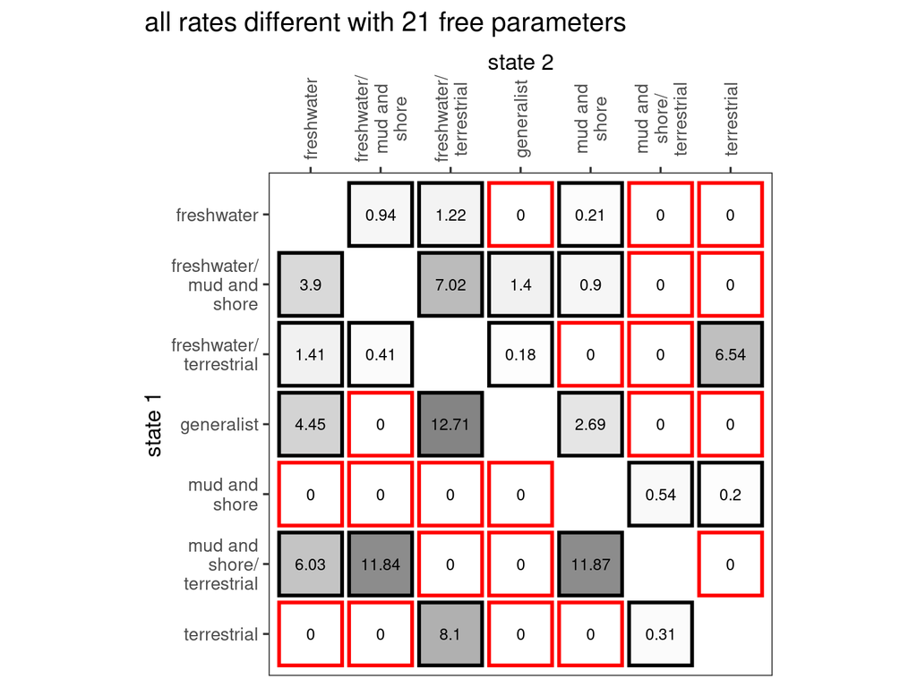

```r
diversitree_df <- get_diversitree_df(mod_custom7, coding$hab_pref_num2, coding$hab_pref)

diversitree_df %>%
  left_join(., select(coding, state_1 = hab_pref, state_1_num = hab_pref_num2, state_1_label = hab_pref_axis)) %>%
  left_join(., select(coding, state_2 = hab_pref, state_2_num = hab_pref_num2, state_2_label = hab_pref_axis)) %>%
  mutate(transition_rate = round(transition_rate, 2)) %>%
  ggplot(., aes(forcats::fct_reorder(state_2_label, state_2_num), forcats::fct_reorder(state_1_label, desc(state_1_num)))) +
  geom_tile(aes(alpha = transition_rate, col = free_param), width = 0.9, height = 0.9, size = 1.1) +
  theme_bw(base_size = 14) +
  theme(panel.grid.major = element_blank(),
  legend.position = 'none',
  axis.text.x.top = element_text(angle = 90, vjust = 0.5),
  plot.title.position = "plot") +
  scale_alpha_continuous(range = c(0, 0.6)) +
  geom_text(aes(label = transition_rate), size = MicrobioUoE::pts(10)) +
  scale_x_discrete(position = 'top', labels = scales::label_wrap(13)) +
  scale_y_discrete(position = 'left', labels = scales::label_wrap(13)) +
  labs(y = 'state 1',
  x = 'state 2',
  title = paste('all rates different with', length(mod_custom7$par), 'free parameters', sep = ' ')) +
  coord_fixed() +
  scale_color_manual(values = c('red', 'black'))
```

```r
ggsave(here('plots/sequencing_rpoB/analyses/transition_matrix_diversitree.png'), last_plot(), height = 6, width = 8)
```

## 10 Run MCMC chain for the best Mk model

We can try and run mcmc on this model.

```r
# set up initial start values
inits_mcmc <- mod_custom7$par

# set up upper and lower limits - limit the values to be < 10 times the max value
lower_mcmc <- rep(0, length(inits_mcmc))
upper_mcmc <- rep(max(inits_mcmc)*10, length(inits_mcmc))

# run first mcmc to tune w
fit_mcmc <- mcmc(lik_custom7, inits_mcmc, nsteps = 10, w = 0.1, upper = upper_mcmc, lower = lower_mcmc)

# tune w for each parameter
w <- diff(sapply(fit_mcmc[2:(ncol(fit_mcmc)-1)], quantile, c(.05, .95)))

# run second mcmc to tune w
fit_mcmc2 <- mcmc(lik_custom7, inits_mcmc, nsteps=100, w=w, upper = upper_mcmc, lower = lower_mcmc)

# tune w for each parameter
w <- diff(sapply(fit_mcmc2[2:(ncol(fit_mcmc2)-1)], quantile, c(.05, .95)))

# run third mcmc for 1000 iter
fit_mcmc3 <- mcmc(lik_custom7, inits_mcmc, nsteps=1000, w=w, upper = upper_mcmc, lower = lower_mcmc)
```

We can easily plot the distribution of these parameter estimates.

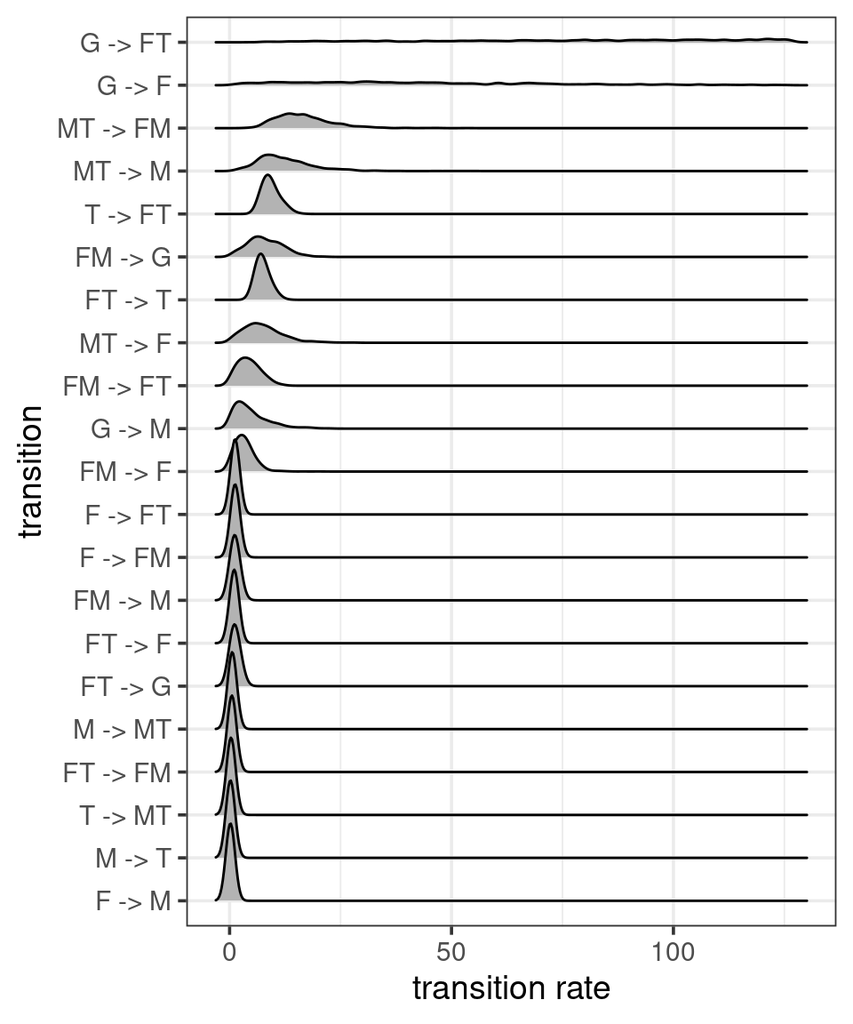

```r
# make data long format
d_mcmc <- pivot_longer(fit_mcmc3, names_to = 'param', values_to = 'transition_rate', cols = starts_with('q')) %>%
  left_join(., select(diversitree_df, param, state_1, state_2)) %>%
  left_join(., select(coding, state_1 = hab_pref, state_1_num = hab_pref_num2, state_1_label = initials)) %>%
  left_join(., select(coding, state_2 = hab_pref, state_2_num = hab_pref_num2, state_2_label = initials)) %>%
  mutate(parameter = paste(state_1_label, '->', state_2_label))

# find 95% CIs and bind with ML estimates
d_mcmc_summary <- d_mcmc %>%
  group_by(parameter, state_1, state_2) %>%
  tidybayes::mean_qi(transition_rate) %>%
  left_join(., select(diversitree_df, state_1, state_2, ml_estimate = transition_rate))

# plot ridge plot
ggplot(d_mcmc, aes(transition_rate, forcats::fct_reorder(parameter, transition_rate))) +
  geom_density_ridges() +
  theme_bw(base_size = 14) +
  labs(x = 'transition rate',
       y = 'transition')
```

From this it is really clear that the model does not have a very good idea about the value of two transitions: (1) generalist -> freshwater and (2) generalist -> freshwater + terrestrial.

We can take 95% CIs and plot these alongside the maximum likelihood estimates.

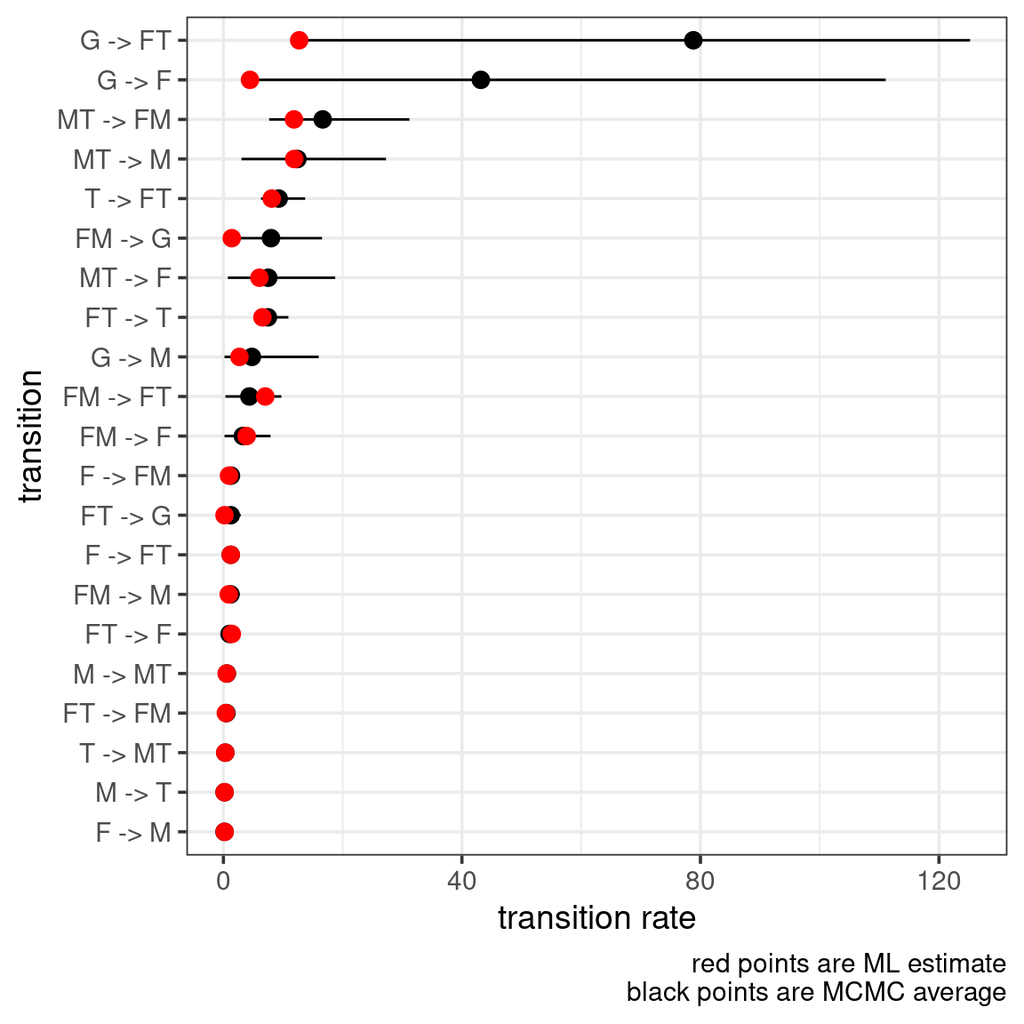

```r
# plot 95% CIs
ggplot(d_mcmc_summary, aes(transition_rate, forcats::fct_reorder(parameter, transition_rate))) +
  geom_linerange(aes(xmin = .lower, xmax = .upper)) +
  geom_point(size = 3) +
  geom_point(aes(x = ml_estimate), size = 3, col = 'red') +
  theme_bw(base_size = 14) +
  labs(x = 'transition rate',
       y = 'transition',
       caption = 'red points are ML estimate\nblack points are MCMC average')
```

So it is abundantly clear that the maximum likelihood model is struggling with some parameters. These are linked to transitions that are not very common. It generally does a much better job when parameters are smaller.

One thing that could be happening is that when one of those transitions is high, the other is lower, we can look at the correlation between generalist -> freshwater (q41) and generalist -> freshwater + terrestrial (q43).

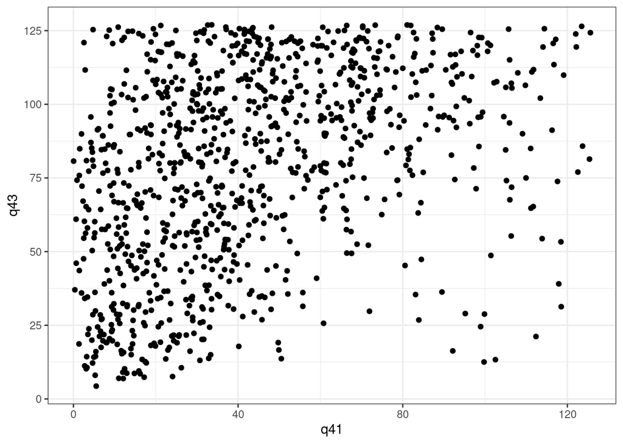

```r
# look at whether the two crazy estimates correlate with each other.
ggplot(fit_mcmc3, aes(q41, q43)) +
  geom_point() +
  theme_bw()
```

## 11 Stochastic character mapping with phytools

We can now pass the best matrix onto phytools to do stochastic character mapping.

```r
# create transition matrix
num_states <- unique(hab_pref) %>% length()

# we will set up the custom matrix, this has 49 numbers and then we have to set the correct numbers to 0
best_matrix <- matrix(1:num_states^2, nrow=num_states)

# make all diagonal numbers NA
for(i in 1:nrow(best_matrix)){
  best_matrix[i,i] <- 0
}

rownames(best_matrix) <- colnames(best_matrix) <- sort(coding$hab_pref)

# populate matrix with estimated parameters from best diversitree model
best_matrix[best_matrix != 0] <- arrange(diversitree_df, state_2, state_1) %>% pull(transition_rate)

# make diagonal values make things sum to 0
diag(best_matrix) <- -rowSums(best_matrix)
```

Run stochastic character mapping

```r
# do stochastic mapping of character traits using phytools
# feed in the best transition matrix previously found using other methods
simmap_best <- make.simmap(tree, hab_pref, nsim = 1000, Q = best_matrix)

# need to split this result up so that files are less than 50MB for GitHub

# number of splits
n_splits <- 10
# find start of each split
splits <- seq(from = 1, to = 1000, by = 1000/10)

# save files out
for(i in 1:length(splits)){
  # save out every 100 sims
  saveRDS(simmap_best[splits[i]:(splits[i]+99)], here(paste("data/sequencing_rpoB/processed/transition_rates/simmap/simmap_", i, '.rds', sep = '')))
}
```

We can then re-load the stochastic character maps in.

```r
# reload simmap files in
simmap_files <- list.files(here("data/sequencing_rpoB/processed/transition_rates/simmap"), full.names = TRUE)
simmap_files <- simmap_files[simmap_files != here('data/sequencing_rpoB/processed/transition_rates/simmap/simmap_summary.rds')]

simmap_best <- purrr::map(simmap_files, readRDS)

simmap_best <- do.call(c, simmap_best)

# load in summary as well!
simmap_summary <- readRDS(here('data/sequencing_rpoB/processed/transition_rates/simmap/simmap_summary.rds'))
```

We can then summarise the stochastic character maps.

```r
# summarise number of switches between states and time spent in each state
simmap_summary <- describe.simmap(simmap_best, plot=FALSE)

# remove the tree element - this is the simmap_best
simmap_summary$tree <- NULL
```

We can now visualise the results. First we can look at the most common transitions.

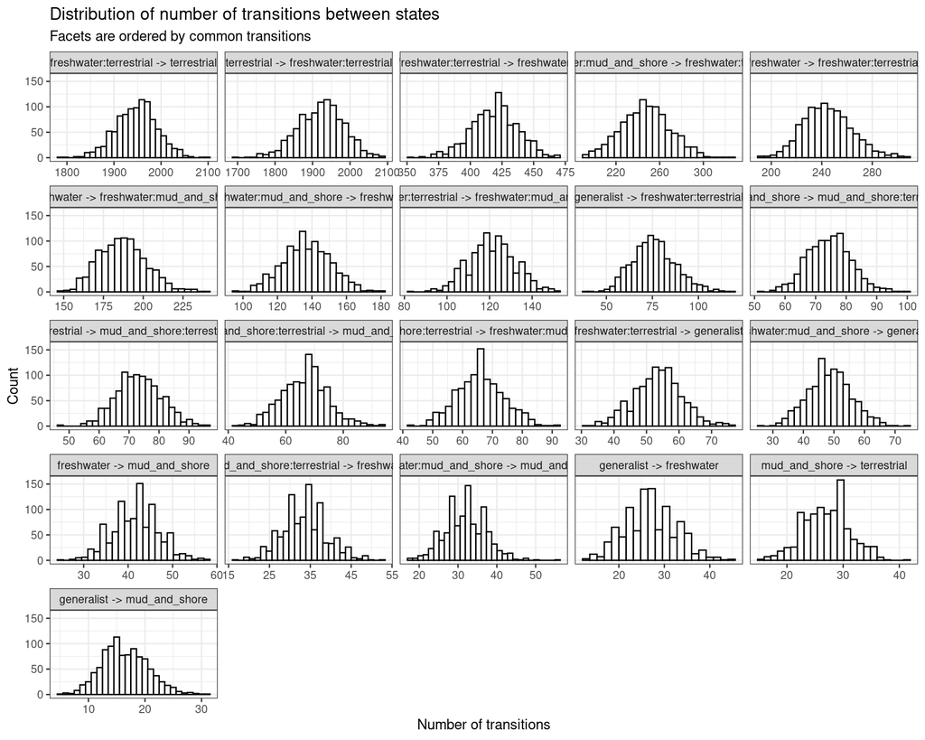

```r
# coerce transitions into dataframe
d_transitions <- as.data.frame(simmap_summary$count, col.names = colnames(simmap_summary$count)) %>%
  mutate(iter = 1:n()) %>%
  pivot_longer(cols = c(everything(), -N, -iter), names_to = 'transition', values_to = 'n_transitions') %>%
  separate(transition, c('state_1', 'state_2'), sep = ',', remove = FALSE) %>%
  mutate(label = gsub(',', ' -> ', transition))

# plot these
group_by(d_transitions, transition) %>%
  filter(max(n_transitions) > 0) %>%
  mutate(average = mean(n_transitions)) %>%
  ungroup() %>%
  mutate(label = fct_reorder(label, desc(average))) %>%
  ggplot() +
  geom_histogram(aes(n_transitions), fill = 'white', col = 'black', binwidth = function(x) (max(x)-min(x))/nclass.FD(x)) +
  facet_wrap(~ label, scales = 'free_x') +
  theme_bw() +
  labs(title = 'Distribution of number of transitions between states',
  subtitle = 'Facets are ordered by common transitions',
  x = 'Number of transitions',
  y = 'Count')
```

We can look at how common transitions are by plotting the averages in a table.

```r
d_transitions_summary <- group_by(d_transitions, iter) %>%
  mutate(prop = n_transitions/sum(n_transitions)) %>%
  group_by(state_1, state_2) %>%
  summarise(ave_num = mean(n_transitions),
            ave_prop = mean(prop),
            lower_ci = quantile(prop, 0.025),
            upper_ci = quantile(prop, 0.975),
            .groups = 'drop') %>%
  arrange(desc(ave_prop)) %>%
  filter(ave_num > 0)

table <- select(d_transitions_summary, state_1, state_2, ave_num, ave_prop) %>%
  mutate(across(starts_with('state'), function(x) gsub('mud_and_shore', 'marine mud', x)),
         across(starts_with('state'), function(x) gsub(':', ' + ', x)),
         ave_prop = round(ave_prop, 2),
         ave_num = round(ave_num, 0))

table_flex <- flextable(table) %>%
  set_header_labels(state_1 = 'from',
                    state_2 = 'to',
                    ave_prop = 'proportion of all transitions',
                    ave_num = 'number of transitions') %>%
  align(align = 'center', part = 'header') %>%
  bold(part = 'header') %>%
  font(fontname = 'Times', part = 'all') %>%
  fontsize(size = 12, part = 'all') %>%
  autofit()

# save out
save_as_image(table_flex, here('plots/sequencing_rpoB/analyses/proportion_of_transitions.png'), zoom = 3, webshot = 'webshot2')
```

```
[1] "/home/padpadpadpad/Desktop/myxo_diversification/plots/sequencing_rpoB/analyses/proportion_of_transitions.png"
```

```r
table_flex
```

common_transitions

| from | to | number of transitions | proportion of all transitions |
| --- | --- | --- | --- |
| freshwater + terrestrial | terrestrial | 1,947 | 0.33 |
| terrestrial | freshwater + terrestrial | 1,922 | 0.33 |
| freshwater + terrestrial | freshwater | 419 | 0.07 |
| freshwater + marine mud | freshwater + terrestrial | 247 | 0.04 |
| freshwater | freshwater + terrestrial | 245 | 0.04 |
| freshwater | freshwater + marine mud | 188 | 0.03 |
| freshwater + marine mud | freshwater | 137 | 0.02 |
| freshwater + terrestrial | freshwater + marine mud | 121 | 0.02 |
| generalist | freshwater + terrestrial | 76 | 0.01 |
| marine mud | marine mud + terrestrial | 75 | 0.01 |
| terrestrial | marine mud + terrestrial | 73 | 0.01 |
| marine mud + terrestrial | marine mud | 67 | 0.01 |
| marine mud + terrestrial | freshwater + marine mud | 66 | 0.01 |
| freshwater + terrestrial | generalist | 53 | 0.01 |
| freshwater + marine mud | generalist | 49 | 0.01 |
| freshwater | marine mud | 42 | 0.01 |
| marine mud + terrestrial | freshwater | 34 | 0.01 |
| freshwater + marine mud | marine mud | 32 | 0.01 |
| generalist | freshwater | 27 | 0.00 |
| marine mud | terrestrial | 27 | 0.00 |
| generalist | marine mud | 16 | 0.00 |

## 12 Plot best transition matrix as a network

We can then plot the best model as a network. The output from the stochastic character mapping also contains information as to the time spent in each state in the phylogenetic tree.

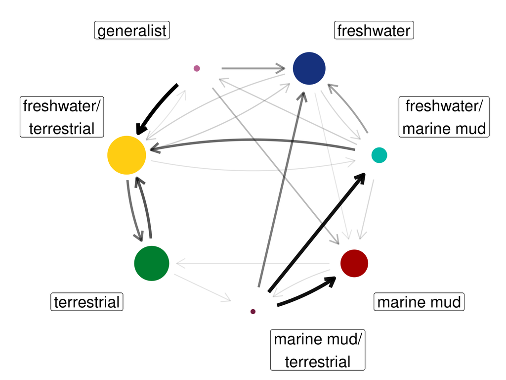

```r
# coerce time into dataframe
d_time <- as.data.frame(simmap_summary$times, col.names = colnames(simmap_summary$times)) %>%
  mutate(n = 1:n()) %>%
  select(-total) %>%
  pivot_longer(cols = c(everything(), -n), names_to = 'state', values_to = 'time') %>%
  group_by(n) %>%
  mutate(prop = time/sum(time)) %>%
  ungroup()

# set colours
cols_hab <- met.brewer('Austria', n = 7)
names(cols_hab) <- c('mud_and_shore', 'freshwater', 'terrestrial', 'freshwater:terrestrial', 'generalist', 'mud_and_shore:terrestrial', 'freshwater:mud_and_shore')
hab_labels <- c('marine mud', 'freshwater', 'terrestrial', 'freshwater + terrestrial', 'generalist', 'marine mud + terrestrial', 'freshwater + marine mud')

# calculate mean time spent in each state
d_timespent <- group_by(d_time, state) %>%
  summarise(mean = mean(prop), .groups = 'drop')

# turn transition matrix into network to plot
d_network <- as_tbl_graph(select(diversitree_df, state_1, state_2, transition_rate)) %>%
  activate(edges) %>%
  filter(!is.na(transition_rate) & transition_rate > 0) %>%
  activate(nodes) %>%
  left_join(., select(d_timespent, name = state, mean)) %>%
  mutate(label = gsub(':', '/', name),
  label = gsub('_', ' ', label),
  label = gsub('mud and shore', 'marine mud', label),
  order = c(1, 2, 6, 7, 3, 4, 5),
  hab1 = gsub(':.*.', '', name),
  hab2 = gsub('.*:', '', name)) %>%
  arrange(order)

p <- ggraph(d_network, layout = 'linear', circular = TRUE) +
  geom_edge_fan(aes(alpha = transition_rate,
                width = transition_rate),
                arrow = arrow(length = unit(4, 'mm')),
                end_cap = circle(10, 'mm'),
                start_cap = circle(10, 'mm')) +
  geom_node_point(aes(size = mean,
                col = name)) +
  theme_void() +
  #geom_node_label(aes(label = label, x=xmin), repel = TRUE) +
  scale_size(range = c(2,20)) +
  scale_edge_width(range = c(0.5, 2)) +
  scale_color_manual('Habitat preference', values = cols_hab, labels = c('terrestrial', 'freshwater', 'marine mud', 'generalist')) +
scale_fill_manual('Habitat preference', values = cols_hab, labels = c('terrestrial', 'freshwater', 'marine mud', 'generalist'))

# grab data for points
point_data <- p$data %>%
  select(x, y, label) %>%
  mutate(nudge_x = ifelse(x < 0, -0.5, 0.5),
  nudge_y = ifelse(y < 0, -0.3, 0.3),
  label = gsub('/', '/\n', label))

p + geom_label(aes(nudge_x + x, nudge_y+y, label = label), point_data, size = MicrobioUoE::pts(18)) +
  theme(legend.position = 'none',
  panel.background = element_rect(fill = 'white', colour = 'white')) +
  coord_cartesian(clip = "off") +
  xlim(c(min(point_data$x) + min(point_data$nudge_x) - 0.3), max(point_data$x) + max(point_data$nudge_x) + 0.3) +
  ylim(c(min(point_data$y) + min(point_data$nudge_y) - 0.1), max(point_data$y) + max(point_data$nudge_y) + 0.1)
```

```r
# save out model
ggsave(here('plots/sequencing_rpoB/analyses/transition_plot_diversitree.png'), last_plot(), height = 6, width = 8)
```

We can look at whether any given state is a net sink or net source using both the total number of transitions and the instantaneous transition rates.

```r
# first with the transition rates
d_source_sink_rate <- select(diversitree_df, away = state_1, into = state_2, transition_rate) %>%
  pivot_longer(cols = c(away, into), names_to = 'direction', values_to = 'habitat_preference') %>%
  group_by(habitat_preference, direction) %>%
  summarise(total_rate = sum(transition_rate), .groups = 'drop') %>%
  pivot_wider(names_from = direction, values_from = total_rate) %>%
  mutate(source_sink1 = away / into,
         source_sink2 = away - into)

table_rate <- select(d_source_sink_rate, habitat_preference, away, into, source_sink1) %>%
  mutate(across(away:source_sink1, round, 2),
         habitat_preference = gsub(':', ' + ', habitat_preference),
         habitat_preference = gsub('_', ' ', habitat_preference)) %>%
  arrange(desc(source_sink1)) %>%
  flextable(.) %>%
  set_header_labels(habitat_preference = 'habitat preference',
                    source_sink1 = 'source sink ratio') %>%
  align(align = 'center', part = 'all') %>%
  align(align = 'left', part = 'body', j = 1) %>%
  bold(part = 'header') %>%
  font(fontname = 'Times', part = 'all') %>%
  fontsize(size = 12, part = 'all') %>%
  autofit()

# save out
save_as_image(table_rate, here('plots/sequencing_rpoB/analyses/source_sink_rate.png'), zoom = 3, webshot = 'webshot2')
```

```
[1] "/home/padpadpadpad/Desktop/myxo_diversification/plots/sequencing_rpoB/analyses/source_sink_rate.png"
```

```r
table_rate
```

| habitat preference | away | into | source sink ratio |
| --- | --- | --- | --- |
| mud and shore + terrestrial | 29.74 | 0.85 | 34.90 |
| generalist | 19.84 | 1.58 | 12.57 |
| terrestrial | 8.41 | 6.74 | 1.25 |
| freshwater + mud and shore | 13.22 | 13.18 | 1.00 |
| freshwater + terrestrial | 8.53 | 29.04 | 0.29 |
| freshwater | 2.36 | 15.80 | 0.15 |
| mud and shore | 0.74 | 15.66 | 0.05 |

```r
# next with simulated counts of transitions on the tree
d_source_sink_count <- select(d_transitions_summary, away = state_1, into = state_2, ave_num) %>%
  pivot_longer(cols = c(away, into), names_to = 'direction', values_to = 'habitat_preference') %>%
  group_by(habitat_preference, direction) %>%
  summarise(total_count = sum(ave_num), .groups = 'drop') %>%
  pivot_wider(names_from = direction, values_from = total_count) %>%
  mutate(source_sink1 = away / into,
         source_sink2 = away - into)

table_count <- select(d_source_sink_count, habitat_preference, away, into, source_sink1) %>%
  mutate(across(away:source_sink1, round, 2),
         habitat_preference = gsub(':', ' + ', habitat_preference),
         habitat_preference = gsub('_', ' ', habitat_preference)) %>%
  arrange(desc(source_sink1)) %>%
  flextable(.) %>%
  set_header_labels(habitat_preference = 'habitat preference',
                    source_sink1 = 'source sink ratio') %>%
  align(align = 'center', part = 'all') %>%
  align(align = 'left', part = 'body', j = 1) %>%
  bold(part = 'header') %>%
  font(fontname = 'Times', part = 'all') %>%
  fontsize(size = 12, part = 'all') %>%
  autofit()

# save out
save_as_image(table_count, here('plots/sequencing_rpoB/analyses/source_sink_count.png'), zoom = 3, webshot = 'webshot2')
```

```
[1] "/home/padpadpadpad/Desktop/myxo_diversification/plots/sequencing_rpoB/analyses/source_sink_count.png"
```

```r
table_count
```

| habitat preference | away | into | source sink ratio |
| --- | --- | --- | --- |
| freshwater + mud and shore | 465.07 | 374.85 | 1.24 |
| generalist | 119.57 | 102.46 | 1.17 |
| mud and shore + terrestrial | 166.27 | 148.22 | 1.12 |
| freshwater + terrestrial | 2,541.13 | 2,489.90 | 1.02 |
| terrestrial | 1,995.34 | 1,974.47 | 1.01 |
| freshwater | 474.02 | 616.73 | 0.77 |
| mud and shore | 102.02 | 156.79 | 0.65 |

## 13 Look at whether some states have more transitions than would be expected

We have a tip estimate of the diversification rate from our BAMM analysis that we have binned into either being “high” or “slow” diversification. We want to run a discrete character evolution model to look at whether transitions across environments result in a shift into the “high” diversification rate state. However, the model would be too big to combine our diversification rate bin and our seven habitat preferences.

Instead we can look for a logical split in the dataset. To do this we can use the mass action expectation that the number of transitions between two habitat preferences should be equivalent to their prevalence in our tip states. We will do this for all available transitions and see which ones are over- or under-represented.

```r
# work out proportion of tips are each habitat preference
d_hab_pref <- group_by(d_meta, habitat_preference) %>%
  tally() %>%
  ungroup() %>%
  mutate(prop = n/sum(n))

# work out expectation
d_expectation <- diversitree_df %>%
  filter(free_param == 'yes') %>%
  select(state_1, state_2) %>%
  left_join(., select(d_hab_pref, state_1 = habitat_preference, state_1_prop = prop)) %>%
  left_join(., select(d_hab_pref, state_2 = habitat_preference, state_2_prop = prop)) %>%
  mutate(expected_prop = state_1_prop * state_2_prop,
         normalised_expectation = expected_prop/sum(expected_prop))

# observed numbers of transitions
d_expectation <- left_join(d_expectation, select(d_transitions_summary, state_1, state_2, ave_num)) %>%
  mutate(ave_num = replace_na(ave_num, 0),
         tot_transitions = sum(ave_num),
         expected_num = tot_transitions*normalised_expectation,
         ratio = ave_num/expected_num) %>%
  select(state_1, state_2, ave_num, expected_num, ratio)

# make this into a table
table_expect <- mutate(d_expectation,
                       across(ave_num:ratio, round, 2),
                       state_1 = gsub(':', ' + ', state_1),
                       state_1 = gsub('_', ' ', state_1),
                       state_2 = gsub(':', ' + ', state_2),
                       state_2 = gsub('_', ' ', state_2)) %>%
  arrange(desc(ratio)) %>%
  flextable(.) %>%
  set_header_labels(state_1 = 'from',
                    state_2 = 'to',
                    ave_num = 'observed number of transitions',
                    expected_num = 'expected number of transitions',
                    ratio = 'ratio'
                    ) %>%
  align(align = 'center', part = 'all') %>%
  align(align = 'left', part = 'body', j = 1) %>%
  bold(part = 'header') %>%
  font(fontname = 'Times', part = 'all') %>%
  fontsize(size = 12, part = 'all') %>%
  autofit()

# save out
save_as_image(table_expect, here('plots/sequencing_rpoB/analyses/expected_transitions.png'), zoom = 3, webshot = 'webshot2')
```

```
[1] "/home/padpadpadpad/Desktop/myxo_diversification/plots/sequencing_rpoB/analyses/expected_transitions.png"
```

```r
table_expect
```

mass_action

| from | to | observed number of transitions | expected number of transitions | ratio |
| --- | --- | --- | --- | --- |
| mud and shore + terrestrial | freshwater + mud and shore | 65.92 | 2.58 | 25.58 |
| freshwater + mud and shore | generalist | 49.06 | 2.58 | 19.04 |
| mud and shore | mud and shore + terrestrial | 74.97 | 15.73 | 4.77 |
| mud and shore + terrestrial | mud and shore | 66.71 | 15.73 | 4.24 |
| terrestrial | mud and shore + terrestrial | 73.25 | 18.71 | 3.92 |
| generalist | freshwater + terrestrial | 76.00 | 24.40 | 3.11 |
| freshwater + terrestrial | generalist | 53.40 | 24.40 | 2.19 |
| mud and shore + terrestrial | freshwater | 33.63 | 17.01 | 1.98 |
| freshwater | freshwater + mud and shore | 187.64 | 97.78 | 1.92 |
| freshwater + terrestrial | terrestrial | 1,947.42 | 1,018.70 | 1.91 |
| terrestrial | freshwater + terrestrial | 1,922.09 | 1,018.70 | 1.89 |
| freshwater + mud and shore | freshwater + terrestrial | 247.14 | 140.30 | 1.76 |
| generalist | freshwater | 27.10 | 17.01 | 1.59 |
| freshwater + mud and shore | freshwater | 136.98 | 97.78 | 1.40 |
| generalist | mud and shore | 16.47 | 15.73 | 1.05 |
| freshwater + terrestrial | freshwater + mud and shore | 121.29 | 140.30 | 0.86 |
| freshwater + terrestrial | freshwater | 419.02 | 925.98 | 0.45 |
| freshwater + mud and shore | mud and shore | 31.90 | 90.44 | 0.35 |
| freshwater | freshwater + terrestrial | 244.67 | 925.98 | 0.26 |
| freshwater | mud and shore | 41.70 | 596.91 | 0.07 |
| mud and shore | terrestrial | 27.05 | 656.68 | 0.04 |

## 14 Calculate the time of evolutionary transitions

There does not seem to be any sensible, easy way of doing this using the stochastic character mapping I have done. Will email Liam Revell but will be a while I imagine.

## 15 Does a habitat transition lead to a faster diversification rate?

## 16 Do generalists and specialists in different environments have different diversification rates

## 17 Useful links used

- [Chapter 13](https://lukejharmon.github.io/pcm/chapter13_chardiv/#ref-Beaulieu2016-ww) of Luke Harmon’s book on phylogenetic comparative methods on “Characters and diversification rates”.
- [Tutorial](https://www.zoology.ubc.ca/prog/diversitree/doc/diversitree-tutorial.pdf) on using the R package **diversitree**.
- [Documentation](https://yulab-smu.top/treedata-book/) of the R package **ggtree** used for plotting phylogenies.
- [Phylo-wiki](https://www.r-phylo.org/wiki/HowTo/Ancestral_State_Reconstruction) help page on ancestral state reconstruction.
- [Github Issue](https://github.com/YuLab-SMU/ggtree/issues/419#issuecomment-877563385) on plotting pie charts for ancestral state reconstructions.